# NYC Shooting Incident Analysis

MS-DS Student

2/26/2022

## New York City Historical Shooting Incident Analysis

1. NYPD Shooting Incident Data (Historic) - data source from https://data.cityofnewyork.us/api/views/833y-fsy8/rows.csv?accessType=DOWNLOAD
2. Setting up libraries needed for data analysis

```r
library(tidyverse)
library(readr)
library(lubridate)
```

```r
URL_IN<-"https://data.cityofnewyork.us/api/views/833y-fsy8/rows.csv?accessType=DOWNLOAD"
nypd_shooting_hist<-read_csv(URL_IN)
```

### To perform the data cleanup and tidy work

Since Data already in one row for each incident, we have to remov unwanted columns in data set for analysis including convert incident occur date from char data type to date type conversion

```r
nypd_shooting_hist <- nypd_shooting_hist %>%
  mutate(OCCUR_DATE  = mdy(OCCUR_DATE)) %>%
  select (-c(X_COORD_CD,Y_COORD_CD,Latitude,Longitude,Lon_Lat))
```

### Print summary information to understand key detail in each column of shooting incident report data

```r
summary(nypd_shooting_hist)
```

```
##   INCIDENT_KEY         OCCUR_DATE          OCCUR_TIME           BORO
##  Min.   :  9953245   Min.   :2006-01-01   Length:23585      Length:23585
##  1st Qu.: 55322804   1st Qu.:2008-12-31   Class1:hms        Class :character
##  Median : 83435362   Median :2012-02-27   Class2:difftime   Mode  :character
##  Mean   :102280741   Mean   :2012-10-05   Mode  :numeric
##  3rd Qu.:150911774   3rd Qu.:2016-03-02
##  Max.   :230611229   Max.   :2020-12-31
##
##     PRECINCT      JURISDICTION_CODE LOCATION_DESC      STATISTICAL_MURDER_FLAG
##  Min.   :  1.00   Min.   :0.000     Length:23585       Mode :logical
##  1st Qu.: 44.00   1st Qu.:0.000     Class :character   FALSE:19085
##  Median : 69.00   Median :0.000     Mode  :character   TRUE :4500
##  Mean   : 66.21   Mean   :0.333
##  3rd Qu.: 81.00   3rd Qu.:0.000
##  Max.   :123.00   Max.   :2.000
##                   NA's   :2
##  PERP_AGE_GROUP       PERP_SEX          PERP_RACE         VIC_AGE_GROUP
##  Length:23585       Length:23585       Length:23585       Length:23585
##  Class :character   Class :character   Class :character   Class :character
##  Mode  :character   Mode  :character   Mode  :character   Mode  :character
##
##
##
##
##    VIC_SEX            VIC_RACE
##  Length:23585       Length:23585
##  Class :character   Class :character
##  Mode  :character   Mode  :character
##
##
##
##
```

### Find the shooting rate on each NY City Borough to understand which part of the city shooting is high and low.

```r
nycy_boro_level_count_by_year <- nypd_shooting_hist %>%
  mutate(month = format(OCCUR_DATE, "%m"), year = format(OCCUR_DATE, "%Y")) %>%
  group_by(year, BORO) %>%
  summarize(shooting_incident_count = n())
print(nycy_boro_level_count_by_year)
```

```
## # A tibble: 75 × 3
## # Groups:   year [15]
##    year  BORO          shooting_incident_count
##    <chr> <chr>                           <int>
##  1 2006  BRONX                             568
##  2 2006  BROOKLYN                          850
##  3 2006  MANHATTAN                         288
##  4 2006  QUEENS                            296
##  5 2006  STATEN ISLAND                      53
##  6 2007  BRONX                             533
##  7 2007  BROOKLYN                          833
##  8 2007  MANHATTAN                         233
##  9 2007  QUEENS                            238
## 10 2007  STATEN ISLAND                      50
## # … with 65 more rows
```

### Understand NYCity Shooting Incidient by Borough over the years through Visualization. It is clearly state that Brooklyn has more shooting incident compare to other borough’s and decline in 2017-2018 and its skyrocked again 2019-2020 across NYC.

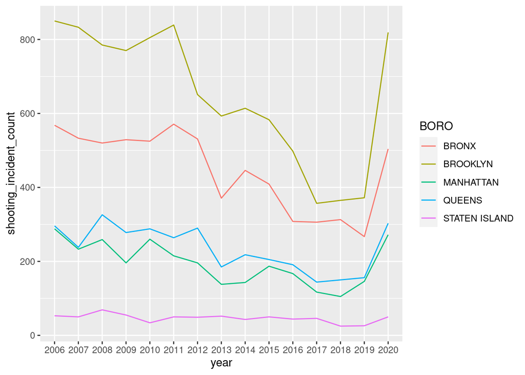

```r
nycy_boro_level_count_by_year %>%
     ggplot( aes(x=year, y=shooting_incident_count, group=BORO, color=BORO)) +
     geom_line()
```

### To understand which race is most victim for shooting incidents and age group distribution across NY City.

1. the first visualization helps to know how race plays vital role in shooting incident by comparing victim race vs suspect race. the BLACK community has more shooting incident in NY city within them where compare to inter-RACE shooting incidents.
2. the second visualization helps to know historically victim age group 18-24 had more shooting incidents from 2006 to 2013 and then supersede by victim age group 25-44. Also the recent years the young kids victim age group <18 significantly reduced compare to 2006-2015 which double amount as recent years 2016-2020.

```r
nycy_shooting_victim_by_race_by_age_grp <- nypd_shooting_hist %>%
  filter(PERP_RACE !="NA" & PERP_RACE !="UNKNOWN" & VIC_RACE !="UNKNOWN") %>%
  mutate(month = format(OCCUR_DATE, "%m"), year = format(OCCUR_DATE, "%Y")) %>%
  group_by(year,VIC_RACE,VIC_AGE_GROUP,PERP_RACE,PERP_AGE_GROUP) %>%
  summarize(shooting_incident_count = n())
```

[output not shown]

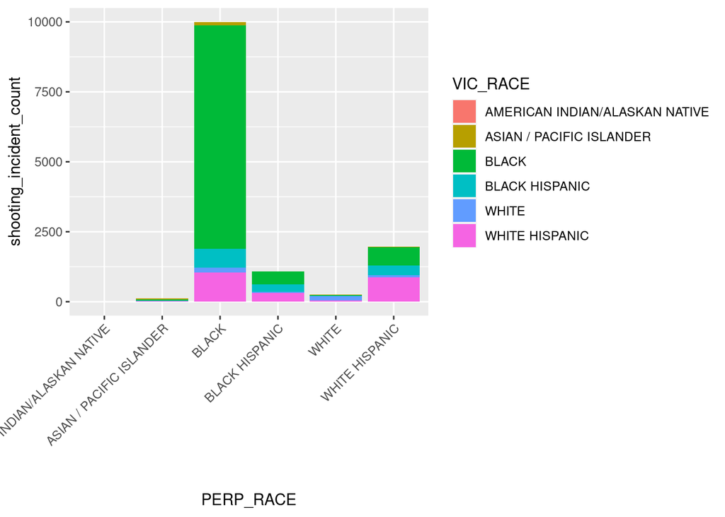

```r
nycy_shooting_victim_by_race_by_age_grp %>%
  ggplot(aes(fill=VIC_RACE,y=shooting_incident_count, x=PERP_RACE)) +
  geom_bar(position="stack", stat="identity") +
  theme(axis.text.x = element_text(angle = 45, vjust = 1, hjust = 1))
```

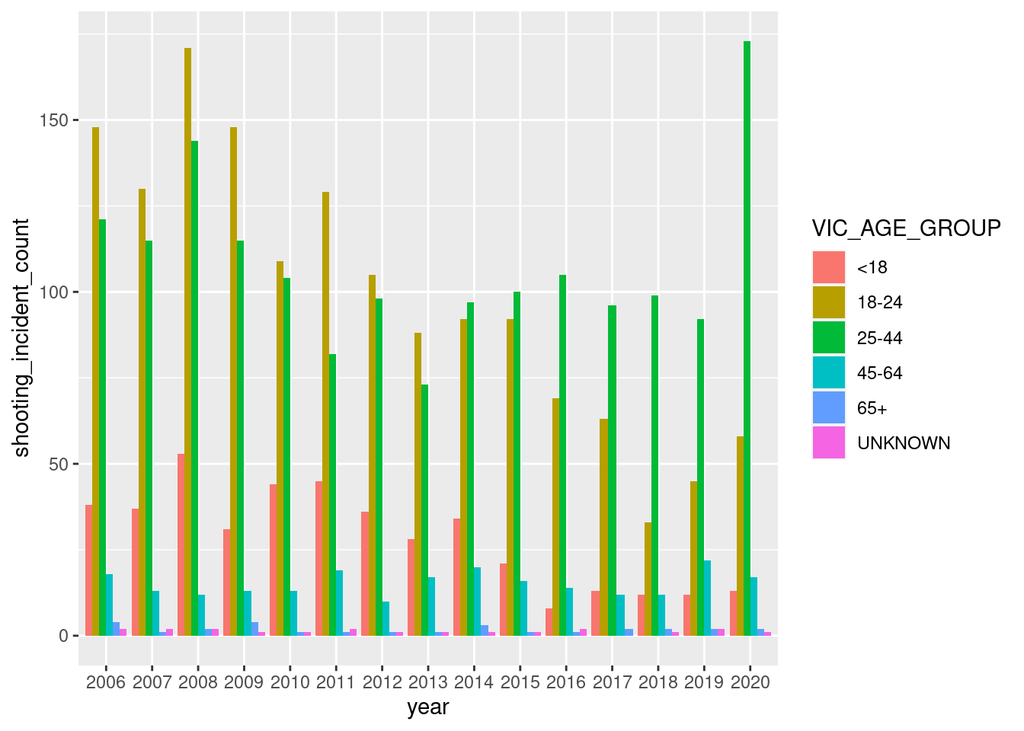

```r
nycy_shooting_victim_by_race_by_age_grp %>%
  ggplot(aes(fill=VIC_AGE_GROUP,y=shooting_incident_count, x=year)) +
  geom_bar(position="dodge", stat="identity")
```

### To find the Age group play roles in shooting incident by analysis victim & suspect age group data. Based on visualization, the age group of suspect 18-24 has very high activity in shooting incidents similar to mid age group 25-44.

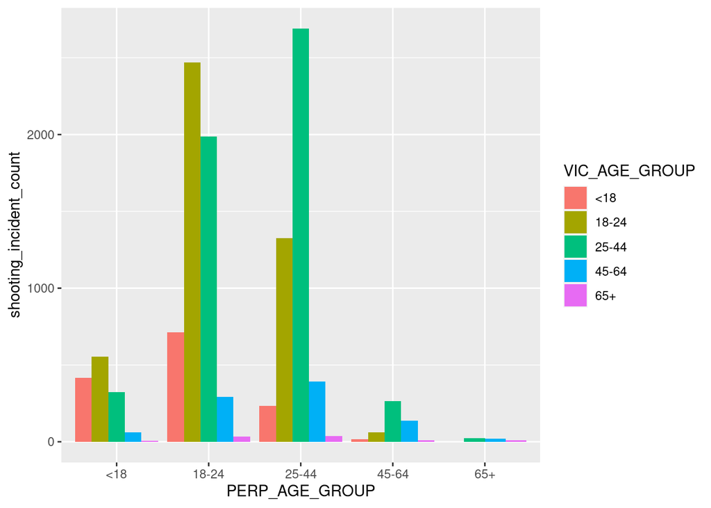

```r
nycy_age_group_shooting_inci_stat <- nypd_shooting_hist %>%
  filter(PERP_AGE_GROUP != "" &  PERP_AGE_GROUP !="UNKNOWN" & VIC_AGE_GROUP !="" &   VIC_AGE_GROUP !="UNKNOWN" & PERP_AGE_GROUP!=1020 & PERP_AGE_GROUP!=940 & PERP_AGE_GROUP!=224 )  %>%
  group_by(PERP_AGE_GROUP,VIC_AGE_GROUP) %>%
  summarize(shooting_incident_count = n())
nycy_age_group_shooting_inci_stat %>%
  ggplot(aes(fill=VIC_AGE_GROUP,y=shooting_incident_count, x=PERP_AGE_GROUP )) +
  geom_bar(position="dodge", stat="identity")
```

### To find the trend in shooting incident historically in NYC over different weather seasons.

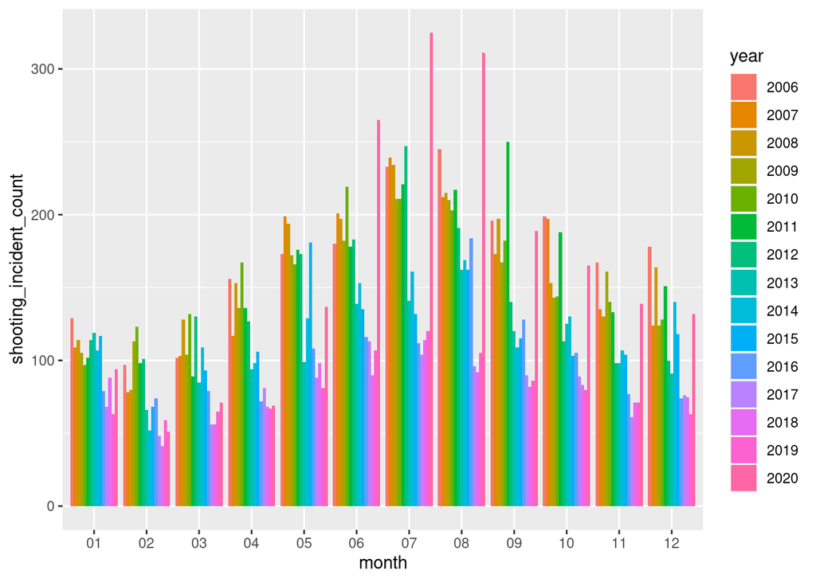

```r
nycy_montth_year_shooting_inci_stat <- nypd_shooting_hist %>%
  mutate(month = format(OCCUR_DATE, "%m"), year = format(OCCUR_DATE, "%Y")) %>%
  group_by(month,year) %>%
  summarize(shooting_incident_count = n())
nycy_montth_year_shooting_inci_stat %>%
  ggplot(aes(fill=year,y=shooting_incident_count, x=month)) +
  geom_bar(position="dodge", stat="identity")
```

### To prepare the Model based on month of the year related to shooting incidents count in NYC.

1. The predicted model doesn’t fit well with actual shooting incidents as related to seasonal changes like summer vs winter months activity changes for people.

```r
nycy_montth_year_shooting_inci_stat <- nypd_shooting_hist %>%
  mutate(month = as.numeric(format(OCCUR_DATE, "%m"))) %>%
  group_by(month) %>%
  summarize(shooting_incident_count = n())

mod<-lm(shooting_incident_count ~  month, data = nycy_montth_year_shooting_inci_stat )
summary(mod)
```

```
##
## Call:
## lm(formula = shooting_incident_count ~ month, data = nycy_montth_year_shooting_inci_stat)
##
## Residuals:
##    Min     1Q Median     3Q    Max
## -552.3 -402.9 -145.7  352.9  810.2
##
## Coefficients:
##             Estimate Std. Error t value Pr(>|t|)
## (Intercept)  1583.89     316.56   5.003 0.000535 ***
## month          58.70      43.01   1.365 0.202284
## ---
## Signif. codes:  0 '***' 0.001 '**' 0.01 '*' 0.05 '.' 0.1 ' ' 1
##
## Residual standard error: 514.3 on 10 degrees of freedom
## Multiple R-squared:  0.157,  Adjusted R-squared:  0.07269
## F-statistic: 1.862 on 1 and 10 DF,  p-value: 0.2023
```

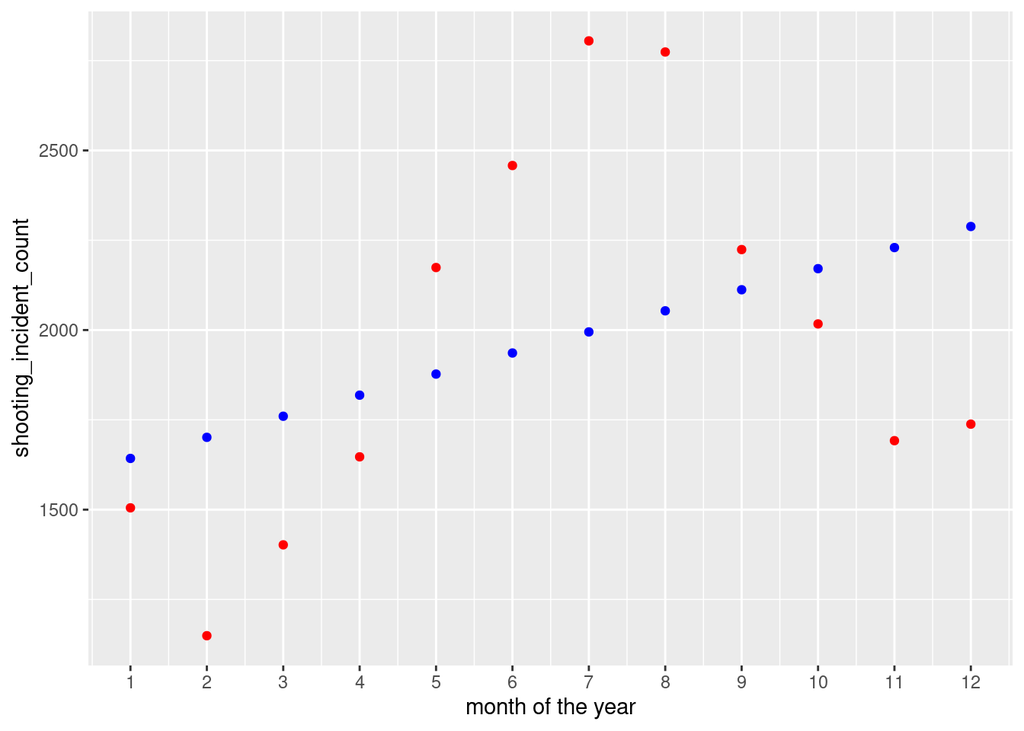

```r
nycy_montth_year_shooting_inci_stat_with_pred <- nycy_montth_year_shooting_inci_stat %>%
  mutate(pred = predict(mod))

nycy_montth_year_shooting_inci_stat_with_pred %>%
  ggplot() +
  geom_point(aes(x=month, y=shooting_incident_count), color="red") +
  geom_point(aes(x=month, y=pred), color="blue")  +
  scale_x_continuous(breaks = seq(1, 12, by = 1), "month of the year")
```

### My point of view about Bias in data source and personal bias mitigation

NYPD police officer may be biased to suspect more Black people which may possible sources of bias including missing unknown data not provide concrete fact. I thought Race play significant role in shooting incident but i don’t want conclude as other factor indeed consider like age group, population density and social economic factors of suspect’s & victim’s including housing and transportation.